# EAS648_Lab2_BH

Bridget Hennessy

2025-11-11

## Exploring the Ann Arbor Arboretum to Identify Areas/Path for Running

```r
library(sf)
library(raster)
library(terra)
library(raster)
library(tmap)
library(tmaptools)
library(lidR)
library(rgl)
library(ForestTools)
library(ggplot2)
library(gstat)

lidar_data <-st_read("Washtenaw_Index.shp")
lidar_data <- st_transform(lidar_data, 4326)
```

Reading in the LAS file for the Arboretum area of Ann Arbor and assessing initial findings.

```r
lasArb <- readLAS("Pointclouds_AnnArbor/297285.las")
```

```r
###NAD83(HARN) / Michigan South
CRS("+init=epsg:8705")
```

[output not shown]

```r
epsg(lasArb) <- 8705
summary(lasArb)
```

```
## class        : LAS (v1.2 format 1)
## memory       : 204.3 Mb
## extent       : 13297500, 13300000, 285000, 287500 (xmin, xmax, ymin, ymax)
## coord. ref.  : NAD83 / Michigan South (ft) + NAVD88 height (ft)
## area         : 6.25 kft²
## points       : 2.98 million points
## type         : airborne
## density      : 0.48 points/ft²
## density      : 0.33 pulses/ft²
## File signature:           LASF
## File source ID:           0
## Global encoding:
##  - GPS Time Type: Standard GPS Time
##  - Synthetic Return Numbers: no
##  - Well Know Text: CRS is GeoTIFF
##  - Aggregate Model: false
## Project ID - GUID:        137f47e7-b013-4fef-7283-5dcd6bba1de9
## Version:                  1.2
## System identifier:        LAStools (c) by rapidlasso GmbH
## Generating software:      las2las (version 200112)
## File creation d/y:        220/2018
## header size:              227
## Offset to point data:     1737
## Num. var. length record:  3
## Point data format:        1
## Point data record length: 28
## Num. of point records:    2975493
## Num. of points by return: 2078321 696822 182506 17281 549
## Scale factor X Y Z:       0.01 0.01 0.01
## Offset X Y Z:             0 0 0
## min X Y Z:                13297500 285000 674.94
## max X Y Z:                13300000 287500 975.53
## Variable Length Records (VLR):
##    Variable Length Record 1 of 4
##        Description: OGC WKT Coordinate System
##        WKT OGC COORDINATE SYSTEM: COMPD_CS["NAD83(HARN) / Michigan South (ft) + NAVD88 height - Geoid12B [...] (truncated)
##    Variable Length Record 2 of 4
##        Description: NIIRS10 Timestamp
##        Extra Bytes Description:
##    Variable Length Record 3 of 4
##        Description: NIIRS10 Tile Index
##    Variable Length Record 4 of 4
##        Description: Geo Key Directory Tag
##        Tags:
##           Key 3072 value 8705
## Extended Variable Length Records (EVLR):  void
```

```r
plot(lasArb)
```

```r
plot(lasArb, bg = "white")
movie3d(spin3d(), duration = 5, movie = exportPath, webshot = F)
```

This shows a moving graphic of the study area, which helped me to see that there might be trees in the northern side too that I should also explore for a running path.

## Exploring the Terrain of the Arboretum

### Digital Terrain Modeling

Now that I have an idea of where canopy cover may be in the study site, I want to get an idea of the terrain to understand where elevation points may be. In my runs, I may want to avoid the higher elevation areas unless purposefully doing hill workouts.

```r
# converting the las into terra dtm
dtm1 <- lidR::rasterize_terrain(lasArb, res = 1, knnidw(k = 6, p = 2), keep_lowest = F)
```

[output not shown]

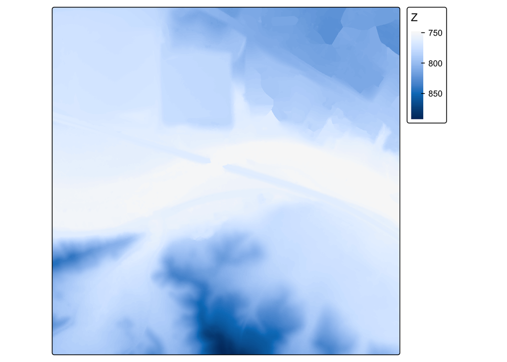

```r
#plot 2d
tm_shape(dtm1)+
  tm_raster(style= "cont")+
  tm_layout(legend.outside = TRUE)
```

```r
#plot 3d
plot_dtm3d(dtm1)
```

These two plots are very helpful. The 2D plot shows that there is steeper topography in both the southern and northeastern areas. It seems that around the river there is flatter topography, which could be a nice, flat area to run to see river views.

Below I plotted the distribution of elevation values of the area. Most of the area is on the lower end of relative elevation (between 750 and 800), which bodes well for my running. I will likely want to avoid or minimize the higher elevations areas if possible, and would want to avoid gaining elevation in too short of a distance.

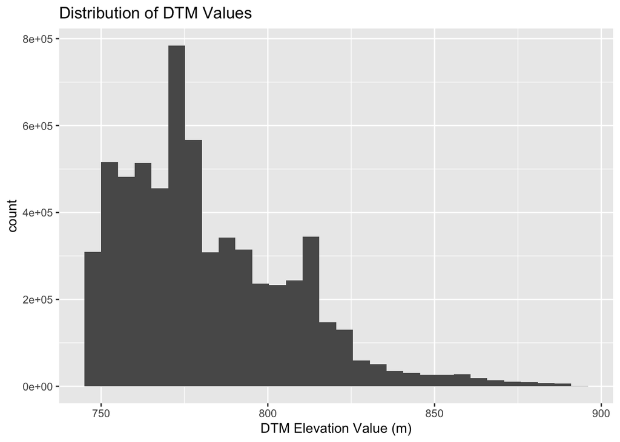

```r
dtmdf <-  as.data.frame(dtm1)

ggplot(dtmdf) +
    geom_histogram(aes(Z)) +
    xlab("DTM Elevation Value (m)") +
    ggtitle("Distribution of DTM Values")
```

## Terrain Modeling

### Rendering shaded DTM

Here I generate a hillshade raster, which simulates sunlight to create shadows/highlights that clarify topographic features. I use two different methods to do this, then plot this.

```r
library(terra) #analysis for slope & aspect
dtm2 <- rasterize_terrain(lasArb, res = 16.4042, algorithm = kriging(k = 40))

slope <- terra::terrain(dtm2, "slope", unit="radians")
aspect <- terra::terrain(dtm2, "aspect", unit="radians")
hs <- shade(slope, aspect, angle=45, direction=315)

tm_shape(hs)+
  tm_raster(style = "cont", palette = "Greys")+
  tm_layout(legend.outside = TRUE)
```

[output not shown]

[output not shown]

[figure not shown]

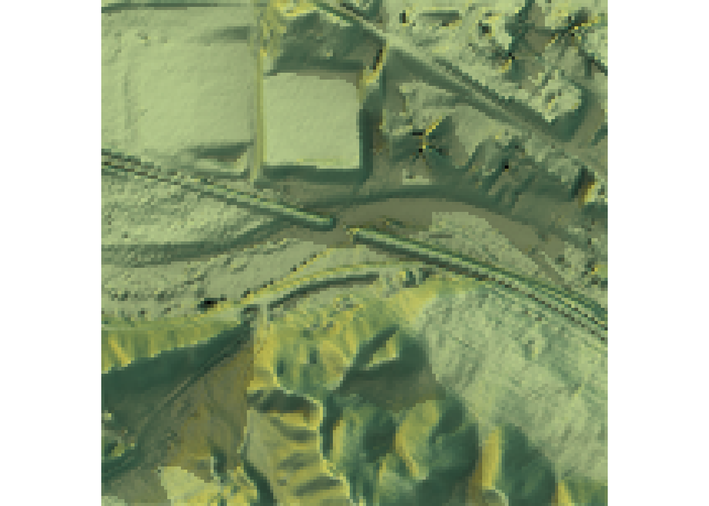

```r
#rayshader method
library(rayshader)
elmat <- raster_to_matrix(dtm2)
map <- elmat %>%
  sphere_shade(texture = "imhof1", progbar = FALSE) %>%
  add_water(detect_water(elmat), color = "imhof1") %>%
  add_shadow(ray_shade(elmat, progbar = FALSE), 0.5) %>%
  add_shadow(ambient_shade(elmat, progbar = FALSE), 0)
plot_map(map)
```

```r
plot_3d(map, elmat, zscale = 5, windowsize = c(800, 800))
```

These graphics show that the southern area is relatively well-shaded besides what looks like high canopy treetops and high ridges. The northern side has some light reflection on what seems to be buildings. The rayshader plot shows this a little more clearly, outlining trees and buildings better and representing contrast from shaded areas better. The rayshader plot also informs me of a railroad crossing through the area, which I had not recognized before from the previous plots. The 3D plot reaffirms these observations, and emphasizes the height/elevation differences on either side of the river. While the southern side is well-shaded so should be conducive to running, it has much higher elevation than the northern side, making my proposed running path a difficult choice.

## Normalized Model

Now I want to understand the height of trees and buildings with the ground at 0, in case there are trees elsewhere that I haven’t recognized due to the elevation that would provide similar canopy cover as the southern area. To do this, I subtract the DTM from LiDAR data.

```r
lasnorm <- normalize_height(lasArb, dtm2, na.rm = TRUE)
plot(lasnorm)
```

## Discussion

This visualization provided new perspective on the relativity of tree height when elevation is taken into account. I also learned that something as simple as a railroad can look very indescribable when viewed from above with different color palettes, as it took me a long time to orient around what was the river and what was the railroad. My research focus showed me that the north side of the study area could be improved by tree plantings as trees are much more populous on the southern, mainly Arboretum side. However, the visualization did not provide much information about what was in the north, besides some distinguishable buildings, so there may be good reasons there are less trees than I would hope (like roads, parking lots, etc). However, I am sure that near the tall buildings and near the square, field-seeming areas that there are opportunities for tree plantings.

There are advantages and complexities of 3D geovisualization. 3D geovisualizations can facilitate learning because a user/viewer can change angles to improve understanding, helping them visualize and retain information. This makes these geovisualizations more understandable and intuitive for the general public, who may be new to whatever information the geovisualization is trying to present. However, 3D geovisualizations are also technologically complex, so creating them is not very accessible, meaning that some very important information may not be presented in the best manner because of lack of knowledge. Additionally, the exploratory nature of 3D could cause privacy or security concerns if that sort of exploratory analysis is done in sensitive areas. However, I think 3D technology is overall becoming more accessible (especially with the assistance of AI), and will become a common form of data presentation. This will be very helpful in both academic and professional environments, especially as modeling future scenarios (related to climate, landscape, urbanization, etc) becomes more important.